# Labb2

```python
!jupyter nbconvert --to html "/content/Labb2.ipynb"
```

## Exercise 1

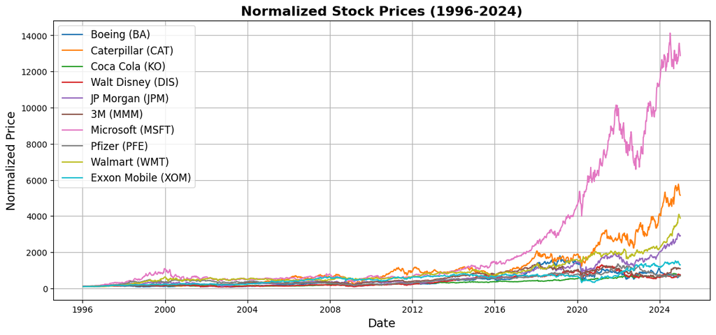

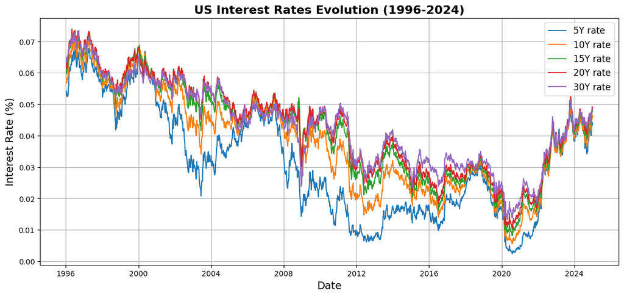

```
Annualized mean log-return
Boeing (BA)           0.333426
Caterpillar (CAT)     0.657070
Coca Cola (KO)        0.327288
Walt Disney (DIS)     0.334960
JP Morgan (JPM)       0.561811
3M (MMM)              0.398703
Microsoft (MSFT)      0.809731
Pfizer (PFE)          0.321441
Walmart (WMT)         0.610100
Exxon Mobile (XOM)    0.427434
dtype: float64

Annualized volatility log-return
Boeing (BA)           0.839492
Caterpillar (CAT)     0.716484
Coca Cola (KO)        0.487539
Walt Disney (DIS)     0.624935
JP Morgan (JPM)       0.782356
3M (MMM)              0.523878
Microsoft (MSFT)      0.626176
Pfizer (PFE)          0.559839
Walmart (WMT)         0.529529
Exxon Mobile (XOM)    0.531596
dtype: float64

5th percentile log-return
Boeing (BA)          -0.075137
Caterpillar (CAT)    -0.072680
Coca Cola (KO)       -0.045082
Walt Disney (DIS)    -0.059509
JP Morgan (JPM)      -0.075636
3M (MMM)             -0.054328
Microsoft (MSFT)     -0.057946
Pfizer (PFE)         -0.051797
Walmart (WMT)        -0.050385
Exxon Mobile (XOM)   -0.051336
Name: 0.05, dtype: float64

95th percentile log-return
```

[output cut: 22 more lines]

```
Exxon Mobile (XOM)    0.154748
dtype: float64

Minimum log-return
Boeing (BA)          -0.582992
Caterpillar (CAT)    -0.224978
Coca Cola (KO)       -0.236452
Walt Disney (DIS)    -0.277276
JP Morgan (JPM)      -0.416844
3M (MMM)             -0.174427
Microsoft (MSFT)     -0.211152
Pfizer (PFE)         -0.227099
Walmart (WMT)        -0.216747
Exxon Mobile (XOM)   -0.223983
dtype: float64
```

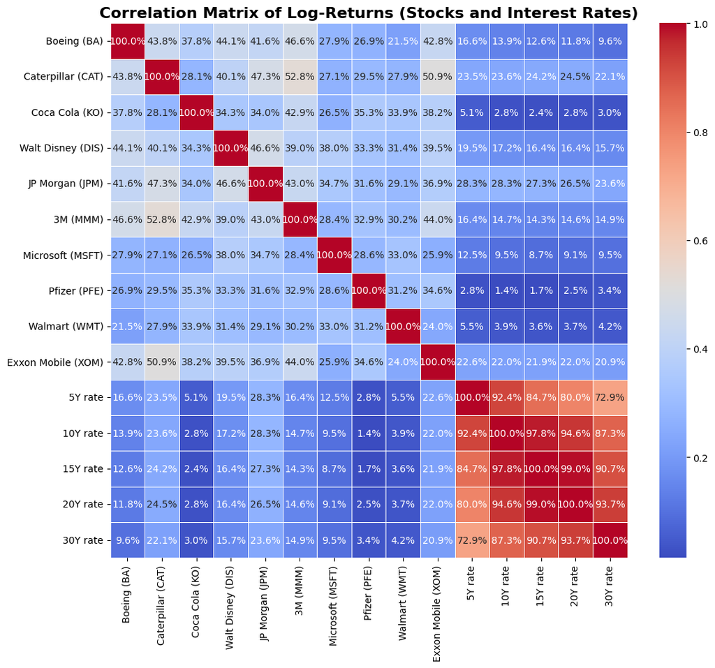

```python
import pandas as pd
import numpy as np
import matplotlib.pyplot as plt
import seaborn as sns

# 1a)---------------------------------------------------------------------------
data = pd.read_csv('/content/market_data.csv', sep=';')

stock_names = ['Boeing (BA)', 'Caterpillar (CAT)', 'Coca Cola (KO)',
               'Walt Disney (DIS)', 'JP Morgan (JPM)', '3M (MMM)',
               'Microsoft (MSFT)', 'Pfizer (PFE)', 'Walmart (WMT)',
               'Exxon Mobile (XOM)']

rate_names = ['5Y rate', '10Y rate', '15Y rate', '20Y rate', '30Y rate']

data.columns = ['Date'] + stock_names + rate_names

data['Date'] = pd.to_datetime(data['Date'])
data = data.set_index('Date')

stocks = data[stock_names]
rates = data[rate_names]

normalized_stocks = (stocks / stocks.iloc[0]) * 100
plt.figure(figsize=(14, 6))

for column in normalized_stocks.columns:
  plt.plot(normalized_stocks.index, normalized_stocks[column], label=column)

plt.title('Normalized Stock Prices (1996-2024)', fontsize=16, fontweight='bold')
plt.xlabel('Date', fontsize=14)
plt.ylabel('Normalized Price', fontsize=14)
plt.legend(loc='best', fontsize=12)
plt.grid(True)
plt.show()



plt.figure(figsize=(14, 6))

for column in rates.columns:
    plt.plot(rates.index, rates[column], label=column)

plt.title('US Interest Rates Evolution (1996-2024)', fontsize=16, fontweight='bold')
plt.xlabel('Date', fontsize=14)
plt.ylabel('Interest Rate (%)', fontsize=14)
plt.legend(loc='best', fontsize=12)
plt.grid(True)
plt.show()



#1 b)---------------------------------------------------------------------------

log_returns = np.log(normalized_stocks / normalized_stocks.shift(1)).dropna()

annualized_mean_log_returns = log_returns.mean() * 252
annualized_volatility_log_returns = log_returns.std() * np.sqrt(252)
percentile_5_log_returns = log_returns.quantile(0.05)
percentile_95_log_returns = log_returns.quantile(0.95)
maximum_log_returns = log_returns.max()
minimum_log_returns = log_returns.min()

print("\nAnnualized mean log-return")
print( annualized_mean_log_returns)
print("\nAnnualized volatility log-return")
print(annualized_volatility_log_returns)
print("\n5th percentile log-return")
print(percentile_5_log_returns)
print("\n95th percentile log-return")
print(percentile_95_log_returns)
print("\nMaximum log-return")
print(maximum_log_returns)
print("\nMinimum log-return")
print(minimum_log_returns)

# 1c)---------------------------------------------------------------------------

combined_data = data[stock_names + rate_names]

combined_log_returns = np.log(combined_data / combined_data.shift(1)).dropna()

correlation_matrix = combined_log_returns.corr()

plt.figure(figsize=(12, 10))
sns.heatmap(correlation_matrix, annot=True, cmap='coolwarm', fmt=".1%", linewidths=.5)
plt.title('Correlation Matrix of Log-Returns (Stocks and Interest Rates)', fontsize=16, fontweight='bold')
plt.show()
```

## Exercise 2

```
VAR(1) model is stable

lagged_coefficients:
                     Boeing (BA)  Caterpillar (CAT)  Coca Cola (KO)  \
Boeing (BA)           -0.085038           0.134290       -0.017806
Caterpillar (CAT)      0.003637           0.001858       -0.048406
Coca Cola (KO)         0.025548           0.044695       -0.051168
Walt Disney (DIS)      0.016087           0.033225       -0.038202
JP Morgan (JPM)        0.014906           0.062840       -0.013515
3M (MMM)               0.039316           0.096859        0.018668
Microsoft (MSFT)       0.020273          -0.017588       -0.037093
Pfizer (PFE)           0.017621           0.023053       -0.037290
Walmart (WMT)          0.043665           0.010588        0.007679
Exxon Mobile (XOM)    -0.003837           0.059203       -0.066267
5Y rate               -0.007493          -0.004801        0.004238
10Y rate              -0.039004          -0.021567       -0.002517
15Y rate              -0.031180          -0.022865       -0.013131
20Y rate              -0.019348          -0.021398       -0.017399
30Y rate              -0.014780          -0.020608       -0.007520

                    Walt Disney (DIS)  JP Morgan (JPM)  3M (MMM)  \
Boeing (BA)                  0.001229        -0.064860 -0.133235
Caterpillar (CAT)            0.040368        -0.012726  0.011745
Coca Cola (KO)              -0.005958        -0.020614 -0.062136
Walt Disney (DIS)           -0.032535         0.013546  0.060702
JP Morgan (JPM)              0.047359        -0.169044 -0.032855
3M (MMM)                    -0.041314        -0.067598 -0.095080
Microsoft (MSFT)            -0.014736         0.033225 -0.031525
Pfizer (PFE)                -0.023130        -0.047356  0.006877
Walmart (WMT)               -0.081566         0.006934 -0.008845
Exxon Mobile (XOM)           0.033325        -0.056082 -0.008365
5Y rate                      0.057183         0.001254 -0.069035
10Y rate                     0.056360         0.015095 -0.047183
15Y rate                     0.056931         0.016081 -0.039592
20Y rate                     0.052972         0.014611 -0.033549
30Y rate                     0.039718         0.008386 -0.017727

                    Microsoft (MSFT)  Pfizer (PFE)  Walmart (WMT)  \
Boeing (BA)                -0.015479      0.012330      -0.045659
Caterpillar (CAT)           0.032633     -0.020052       0.038015
```

[output cut: 49 more lines]

```
Boeing (BA): 0.051650
Caterpillar (CAT): 0.044902
Coca Cola (KO): 0.030179
Walt Disney (DIS): 0.039122
JP Morgan (JPM): 0.048427
3M (MMM): 0.032384
Microsoft (MSFT): 0.039122
Pfizer (PFE): 0.034927
Walmart (WMT): 0.032516
Exxon Mobile (XOM): 0.032836
5Y rate: 0.060477
10Y rate: 0.045380
15Y rate: 0.038454
20Y rate: 0.034822
30Y rate: 0.033489
```

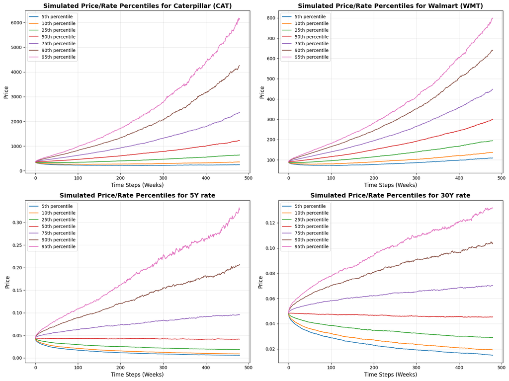

```
--- Percentiles at Time Step 240 ---
```

|  | 5th Percentile | 10th Percentile | 25th Percentile | 50th Percentile | 75th Percentile | 90th Percentile | 95th Percentile |
| --- | --- | --- | --- | --- | --- | --- | --- |
| Caterpillar (CAT) | 218.004717 | 281.489887 | 423.507071 | 675.713755 | 1071.206852 | 1609.951118 | 2107.021571 |
| Walmart (WMT) | 80.442984 | 95.506308 | 123.065395 | 166.471699 | 218.703720 | 283.365176 | 331.788990 |
| 5Y rate | 0.009852 | 0.013794 | 0.023841 | 0.042611 | 0.075997 | 0.132206 | 0.186728 |
| 30Y rate | 0.021231 | 0.025365 | 0.033992 | 0.046213 | 0.063549 | 0.084488 | 0.100652 |

```
--- Percentiles at Time Step 480 ---
```

|  | 5th Percentile | 10th Percentile | 25th Percentile | 50th Percentile | 75th Percentile | 90th Percentile | 95th Percentile |
| --- | --- | --- | --- | --- | --- | --- | --- |
| Caterpillar (CAT) | 246.691709 | 357.311389 | 640.142843 | 1225.696792 | 2366.326949 | 4257.987469 | 6167.418618 |
| Walmart (WMT) | 109.173894 | 136.633207 | 194.634120 | 300.135520 | 447.575917 | 640.405554 | 798.998839 |
| 5Y rate | 0.005675 | 0.008764 | 0.018221 | 0.041497 | 0.095666 | 0.206950 | 0.327456 |
| 30Y rate | 0.014879 | 0.019178 | 0.029000 | 0.045365 | 0.070078 | 0.103891 | 0.131573 |

```python
import pandas as pd
import numpy as np
import matplotlib.pyplot as plt

#2 a)---------------------------------------------------------------------------
data = pd.read_csv('/content/market_data.csv', sep=';')

stock_names = ['Boeing (BA)', 'Caterpillar (CAT)', 'Coca Cola (KO)',
               'Walt Disney (DIS)', 'JP Morgan (JPM)', '3M (MMM)',
               'Microsoft (MSFT)', 'Pfizer (PFE)', 'Walmart (WMT)',
               'Exxon Mobile (XOM)']

rate_names = ['5Y rate', '10Y rate', '15Y rate', '20Y rate', '30Y rate']

data.columns = ['Date'] + stock_names + rate_names

data['Date'] = pd.to_datetime(data['Date'])
data = data.set_index('Date')

stocks = data[stock_names]
rates = data[rate_names]

combined_data = data[stock_names + rate_names]
combined_log_returns = np.log(combined_data / combined_data.shift(1)).dropna()

Y = combined_log_returns.iloc[1:].to_numpy()
Ylag = combined_log_returns.shift(1).iloc[1:].to_numpy()
T, k = Y.shape

M = np.c_[np.ones((T,1)), Ylag]
MtM = M.T @ M

lagged_coefficients = np.zeros((k,k))
intercept = np.zeros(k)
resids = np.zeros_like(Y)

all_names = stock_names + rate_names

for j, column in enumerate(all_names):
  V = Y[:, j]
  Xty = M.T @ V
  a_par = np.linalg.pinv(MtM) @ Xty # Normal equation a(k) = (M^T(k)M(k))^-1M^T(k)*V(k)
  intercept[j] = a_par[0]
  lagged_coefficients[j, :] = a_par[1:]
  resids[:, j] = V - M @ a_par

eigenvalues, eigenvectors = np.linalg.eig(lagged_coefficients)

if np.all(np.abs(eigenvalues) < 1):
  print("VAR(1) model is stable")
else:
  print("VAR(1) model is not stable")
print("\nlagged_coefficients:\n", pd.DataFrame(lagged_coefficients, index=all_names, columns=all_names))

# 2 b) -------------------------------------------------------------------------

residual_volatilities = np.std(resids, axis=0)

print("\nVolatilities of VAR Residuals:")
for i, name in enumerate(all_names):
    print(f"{name}: {residual_volatilities[i]:.6f}")


# 2 c)--------------------------------------------------------------------------

residual_covariance = np.cov(resids.T)
n_scenarios = 5000
n_timesteps = 480

shocks = np.random.multivariate_normal(np.zeros(k), residual_covariance, size=(n_scenarios, n_timesteps)) #DUBELKOLLA
simulated_log_returns = np.zeros((n_scenarios, n_timesteps, k))

last_observed_log_returns = combined_log_returns.iloc[-1].to_numpy()
simulated_log_returns[:, 0, :] = last_observed_log_returns


for i in range(n_scenarios):
    for t in range(1, n_timesteps):
        expected_log_return = intercept + lagged_coefficients @ simulated_log_returns[i, t-1, :]
        simulated_log_returns[i, t, :] = expected_log_return + shocks[i, t, :]


simulated_levels = np.zeros((n_scenarios, n_timesteps, k))
last_observed_levels = combined_data.iloc[-1].to_numpy()
simulated_levels[:, 0, :] = last_observed_levels


for i in range(n_scenarios):
    for t in range(1, n_timesteps):
        simulated_levels[i, t, :] = simulated_levels[i, t-1, :] * np.exp(simulated_log_returns[i, t, :])


selected_indices = [all_names.index('Caterpillar (CAT)'),
                    all_names.index('Walmart (WMT)'),
                    all_names.index('5Y rate'),
                    all_names.index('30Y rate')]

selected_names = [all_names[i] for i in selected_indices]
simulated_selected_levels = simulated_levels[:, :, selected_indices]
percentiles_to_calculate = [5, 10, 25, 50, 75, 90, 95]
percentile_values = np.zeros((n_timesteps, len(percentiles_to_calculate), len(selected_indices)))

for t in range(n_timesteps):
    for p_idx, p in enumerate(percentiles_to_calculate):
        for asset_idx in range(len(selected_indices)):
            percentile_values[t, p_idx, asset_idx] = np.percentile(simulated_selected_levels[:, t, asset_idx], p)


fig, axes = plt.subplots(nrows=2, ncols=2, figsize=(16, 12))
axes = axes.flatten()

for asset_plot_idx, asset_name in enumerate(selected_names):
    ax = axes[asset_plot_idx]
    for p_idx, p in enumerate(percentiles_to_calculate):
        ax.plot(percentile_values[:, p_idx, asset_plot_idx], label=f'{p}th percentile')

    ax.set_title(f'Simulated Price/Rate Percentiles for {asset_name}', fontsize=14, fontweight='bold')
    ax.set_xlabel('Time Steps (Weeks)', fontsize=12)
    ax.set_ylabel('Price', fontsize=12)
    ax.legend(fontsize=10)
    ax.grid(True, alpha=0.3)

plt.tight_layout()
plt.show()

time_periods_for_tables = [240, 480]

for time_step in time_periods_for_tables:
    print(f"\n--- Percentiles at Time Step {time_step} ---")
    table_data = {}
    for p_idx, p in enumerate(percentiles_to_calculate):
        table_data[f'{p}th Percentile'] = percentile_values[time_step-1, p_idx, :]

    percentile_table = pd.DataFrame(table_data, index=selected_names)
    display(percentile_table)
```

## Exercise 3

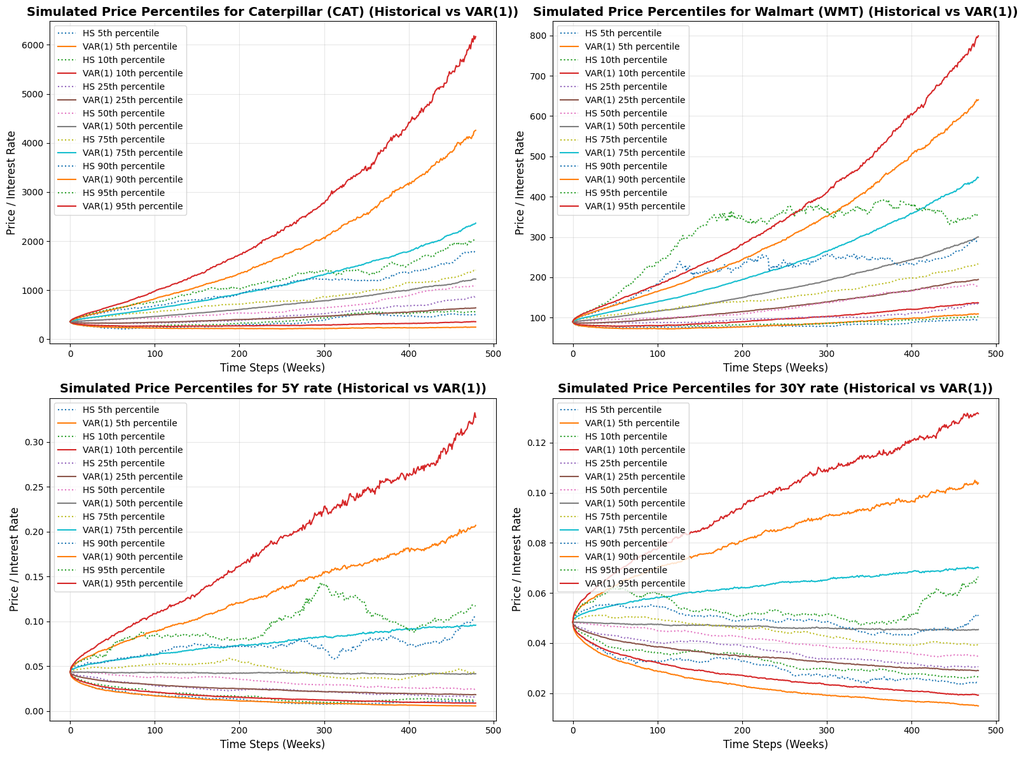

```
--- Historical Simulation Percentiles at Time Step 240 ---
```

|  | 5th Percentile | 10th Percentile | 25th Percentile | 50th Percentile | 75th Percentile | 90th Percentile | 95th Percentile |
| --- | --- | --- | --- | --- | --- | --- | --- |
| Caterpillar (CAT) | 318.715974 | 351.540172 | 446.073756 | 548.762757 | 768.858101 | 1053.922759 | 1172.995158 |
| Walmart (WMT) | 80.397900 | 84.413471 | 96.943466 | 118.743796 | 145.592099 | 227.839753 | 351.358278 |
| 5Y rate | 0.009969 | 0.012698 | 0.024655 | 0.032364 | 0.048301 | 0.070546 | 0.099022 |
| 30Y rate | 0.030637 | 0.032197 | 0.036774 | 0.041215 | 0.044677 | 0.048412 | 0.053242 |

```
--- Historical Simulation Percentiles at Time Step 480 ---
```

|  | 5th Percentile | 10th Percentile | 25th Percentile | 50th Percentile | 75th Percentile | 90th Percentile | 95th Percentile |
| --- | --- | --- | --- | --- | --- | --- | --- |
| Caterpillar (CAT) | 505.838894 | 561.209471 | 874.240237 | 1091.340896 | 1411.099209 | 1819.202768 | 2034.768528 |
| Walmart (WMT) | 93.943146 | 102.473478 | 134.992543 | 178.858496 | 233.102769 | 286.001540 | 348.525095 |
| 5Y rate | 0.010117 | 0.011765 | 0.015424 | 0.024452 | 0.043146 | 0.105739 | 0.117396 |
| 30Y rate | 0.023866 | 0.026464 | 0.030544 | 0.034736 | 0.039275 | 0.050837 | 0.066260 |

```python
import pandas as pd
import numpy as np
import matplotlib.pyplot as plt
from scipy.optimize import minimize


data = pd.read_csv('/content/market_data.csv', sep=';')

stock_names = ['Boeing (BA)', 'Caterpillar (CAT)', 'Coca Cola (KO)',
               'Walt Disney (DIS)', 'JP Morgan (JPM)', '3M (MMM)',
               'Microsoft (MSFT)', 'Pfizer (PFE)', 'Walmart (WMT)',
               'Exxon Mobile (XOM)']

rate_names = ['5Y rate', '10Y rate', '15Y rate', '20Y rate', '30Y rate']
data.columns = ['Date'] + stock_names + rate_names

data['Date'] = pd.to_datetime(data['Date'])
data = data.set_index('Date')

stocks = data[stock_names]
rates = data[rate_names]

combined_data = data[stock_names + rate_names]
combined_log_returns = np.log(combined_data / combined_data.shift(1)).dropna()

n_scenarios = 5000
n_timesteps = 480

historical_log_returns = combined_log_returns.values

last_observed_levels = combined_data.iloc[-1].to_numpy()
simulated_levels_hs = np.zeros((n_scenarios, n_timesteps, len(stock_names) + len(rate_names)))
simulated_levels_hs[:, 0, :] = last_observed_levels

for i in range(n_scenarios):
    start_index = np.random.randint(0, len(historical_log_returns) - n_timesteps)
    historical_path = historical_log_returns[start_index : start_index + n_timesteps]

    for t in range(1, n_timesteps):
        simulated_log_return_t = historical_path[t, :]
        simulated_levels_hs[i, t, :] = simulated_levels_hs[i, t-1, :] * np.exp(simulated_log_return_t)


all_names = stock_names + rate_names
selected_indices = [all_names.index('Caterpillar (CAT)'),
                    all_names.index('Walmart (WMT)'),
                    all_names.index('5Y rate'),
                    all_names.index('30Y rate')]

selected_names = [all_names[i] for i in selected_indices]
simulated_selected_levels_hs = simulated_levels_hs[:, :, selected_indices]
percentiles_to_calculate = [5, 10, 25, 50, 75, 90, 95]
percentile_values_hs = np.zeros((n_timesteps, len(percentiles_to_calculate), len(selected_indices)))

for t in range(n_timesteps):
    for p_idx, p in enumerate(percentiles_to_calculate):
        for asset_idx in range(len(selected_indices)):
            percentile_values_hs[t, p_idx, asset_idx] = np.percentile(simulated_selected_levels_hs[:, t, asset_idx], p)


fig, axes = plt.subplots(nrows=2, ncols=2, figsize=(16, 12))
axes = axes.flatten()

for asset_plot_idx, asset_name in enumerate(selected_names):
    ax = axes[asset_plot_idx]
    for p_idx, p in enumerate(percentiles_to_calculate):
        ax.plot(percentile_values_hs[:, p_idx, asset_plot_idx], linestyle='dotted', label=f'HS {p}th percentile')
        if 'percentile_values' in globals():
             ax.plot(percentile_values[:, p_idx, asset_plot_idx], linestyle='solid', label=f'VAR(1) {p}th percentile')


    ax.set_title(f'Simulated Price Percentiles for {asset_name} (Historical vs VAR(1))', fontsize=14, fontweight='bold')
    ax.set_xlabel('Time Steps (Weeks)', fontsize=12)
    ax.set_ylabel('Price / Interest Rate', fontsize=12)
    ax.legend(fontsize=10)
    ax.grid(True, alpha=0.3)

plt.tight_layout()
plt.show()

time_periods_for_tables = [240, 480]

for time_step in time_periods_for_tables:
    print(f"\n--- Historical Simulation Percentiles at Time Step {time_step} ---")
    table_data_hs = {}
    for p_idx, p in enumerate(percentiles_to_calculate):
        table_data_hs[f'{p}th Percentile'] = percentile_values_hs[time_step-1, p_idx, :]

    percentile_table_hs = pd.DataFrame(table_data_hs, index=selected_names)
    display(percentile_table_hs)
```

### Exercise 4

Discussion Task 4a:

In the first two plots of residuals we can see that most lags fall within our confidence interval, only 7 fall outside for Caterpillar and only 5 for the 5 year rate. This is a good sign and it indicates that our VAR(1) model has successfully captured the linear dependencies since the returns shouldn't be predictable.

However, we can see that the ACF of the squared residuals shows significant autocorrelation at several lags (around 26 for Caterpillar and 44 for the 5-year rate if I counted correctly). This indicates that there exists volatility clustering, which tells us that we need to use GARCH to model the time-varying volatility in order to better capture this phenomenon.

```
VAR(1) model estimated: 15 assets, 1511 observations
Model stability: max |eigenvalue| = 0.2513
```

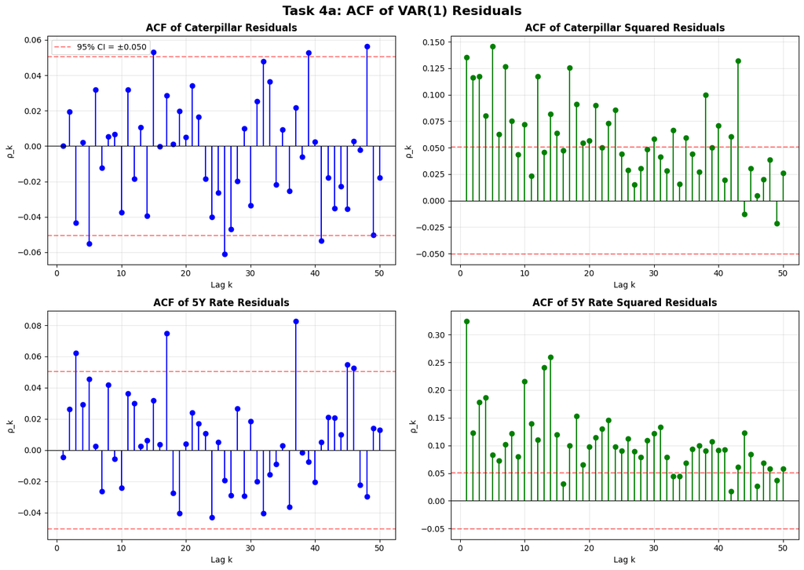

```
DCC parameters: delta=0.010000, gamma=0.970000
Persistence (delta+gamma)=0.980000
```

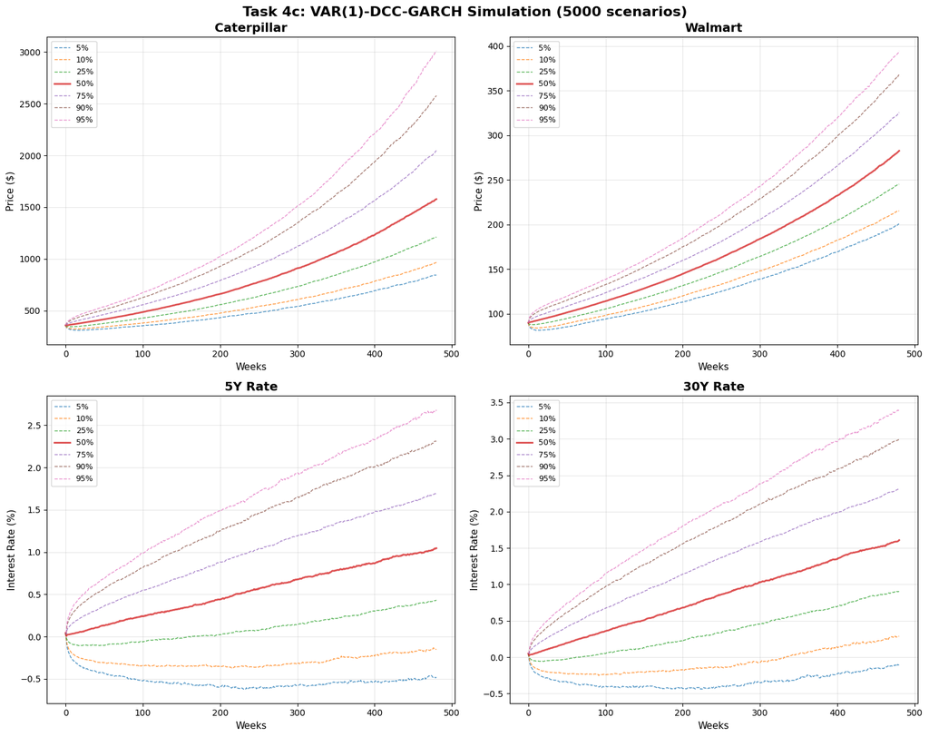

```
======================================================================
SIMULATION PERCENTILES
======================================================================

Week 240 (4.6 years):
Asset                P 5% P10% P25% P50% P75% P90% P95%
----------------------------------------------------------------------
Caterpillar          $473.63 $527.07 $621.83 $753.20 $912.04 $1074.57 $1193.22
Walmart              $122.71 $130.78 $143.79 $159.37 $177.01 $194.78 $206.69
5Y Rate              -0.61% -0.36%  0.07%  0.55%  1.01%  1.42%  1.65%
30Y Rate             -0.41% -0.14%  0.32%  0.82%  1.33%  1.77%  2.04%

Week 480 (9.2 years):
Asset                P 5% P10% P25% P50% P75% P90% P95%
----------------------------------------------------------------------
Caterpillar          $843.50 $967.06 $1211.34 $1577.40 $2046.59 $2577.85 $3008.43
Walmart              $200.43 $215.12 $245.30 $282.64 $325.69 $367.90 $394.50
5Y Rate              -0.48% -0.15%  0.43%  1.05%  1.69%  2.31%  2.68%
30Y Rate             -0.11%  0.29%  0.90%  1.61%  2.31%  3.01%  3.40%

Simulation complete.
```

```python
import pandas as pd
import numpy as np
import matplotlib.pyplot as plt
from scipy.optimize import minimize
import warnings
# warnings.filterwarnings('ignore')

# Load data
data = pd.read_csv('/content/market_data.csv', sep=';')

stock_names = ['Boeing (BA)', 'Caterpillar (CAT)', 'Coca Cola (KO)',
               'Walt Disney (DIS)', 'JP Morgan (JPM)', '3M (MMM)',
               'Microsoft (MSFT)', 'Pfizer (PFE)', 'Walmart (WMT)',
               'Exxon Mobile (XOM)']
rate_names = ['5Y rate', '10Y rate', '15Y rate', '20Y rate', '30Y rate']

display_names = ['Boeing', 'Caterpillar', 'Coca Cola', 'Walt Disney', 'JP Morgan',
                 '3M', 'Microsoft', 'Pfizer', 'Walmart', 'Exxon Mobile',
                 '5Y rate', '10Y rate', '15Y rate', '20Y rate', '30Y rate']

data.columns = ['Date'] + stock_names + rate_names
data['Date'] = pd.to_datetime(data['Date'])
data = data.set_index('Date')

combined_data = data[stock_names + rate_names]

# Calculate log-returns
Y = np.log(combined_data / combined_data.shift(1)).dropna()

# VAR(1) estimation: Y_t = c + Phi * Y_{t-1} + epsilon_t
Y_t = Y.iloc[1:].values
Y_lag = Y.iloc[:-1].values
T, K = Y_t.shape
X = np.c_[np.ones(T), Y_lag]

c = np.zeros(K)
Phi = np.zeros((K, K))
epsilon = np.zeros_like(Y_t)

for j in range(K):
    beta = np.linalg.lstsq(X, Y_t[:, j], rcond=None)[0]
    c[j], Phi[:, j], epsilon[:, j] = beta[0], beta[1:], Y_t[:, j] - X @ beta

print(f"VAR(1) model estimated: {K} assets, {T} observations")
print(f"Model stability: max |eigenvalue| = {np.max(np.abs(np.linalg.eigvals(Phi))):.4f}")

# TASK 4a: ACF ANALYSIS

def calculate_acf(data, max_lag=50):
    """Calculate ACF: rho_k = C_k / C_0"""
    T, y_bar = len(data), np.mean(data)
    y_demeaned = data - y_bar
    C_0 = np.mean(y_demeaned**2)
    return np.array([np.mean(y_demeaned[:-k] * y_demeaned[k:]) * (T-k)/T / C_0
                     for k in range(1, min(max_lag + 1, T))])

cat_epsilon = epsilon[:, 1]
rate_5y_epsilon = epsilon[:, 10]

cat_acf = calculate_acf(cat_epsilon, 50)
cat_acf_sq = calculate_acf(cat_epsilon**2, 50)
rate_acf = calculate_acf(rate_5y_epsilon, 50)
rate_acf_sq = calculate_acf(rate_5y_epsilon**2, 50)

fig, axes = plt.subplots(2, 2, figsize=(14, 10))
fig.suptitle('Task 4a: ACF of VAR(1) Residuals', fontsize=16, fontweight='bold')
lags = np.arange(1, 51)
ci = 1.96 / np.sqrt(len(cat_epsilon))

plot_configs = [
    (axes[0,0], cat_acf, 'Caterpillar Residuals', 'blue'),
    (axes[0,1], cat_acf_sq, 'Caterpillar Squared Residuals', 'green'),
    (axes[1,0], rate_acf, '5Y Rate Residuals', 'blue'),
    (axes[1,1], rate_acf_sq, '5Y Rate Squared Residuals', 'green')
]

for ax, acf_data, title, color in plot_configs:
    ax.stem(lags, acf_data, linefmt=color, markerfmt=f'{color[0]}o', basefmt=' ')
    ax.axhline(0, color='black', linewidth=0.8)
    ax.axhline(ci, color='red', linestyle='--', alpha=0.5, label=f'95% CI = ±{ci:.3f}')
    ax.axhline(-ci, color='red', linestyle='--', alpha=0.5)
    ax.set_title(f'ACF of {title}', fontweight='bold')
    ax.set_xlabel('Lag k')
    ax.set_ylabel('ρ_k')
    ax.grid(True, alpha=0.3)
    if ax == axes[0,0]:
        ax.legend()

plt.tight_layout()
plt.show()

# TASK 4b: DCC-GARCH ESTIMATION
# Following estimation procedure from lecture notes

# STEP 1: Estimate GARCH(1,1) for each asset
# sigma^2_{t,i} = omega_i + alpha_i * Y^2_{t-1,i} + beta_i * sigma^2_{t-1,i}

def garch_11(params, returns):
    """GARCH(1,1) log-likelihood"""
    omega, alpha, beta = params
    T = len(returns)
    sigma_sq = np.zeros(T)
    sigma_sq[0] = returns.var()

    log_likelihood = 0.0
    for t in range(1, T):
        sigma_sq[t] = omega + alpha * returns[t-1]**2 + beta * sigma_sq[t-1]
        log_likelihood += 0.5 * (np.log(sigma_sq[t]) + returns[t]**2 / sigma_sq[t])

    return log_likelihood, sigma_sq

def garch_mle(params, returns):
    return garch_11(params, returns)[0]

garch_params = np.zeros((K, 3))
sigma_t = np.zeros_like(epsilon)

for i in range(K):
    initial = [0.00001, 0.05, 0.85]
    bounds = [(1e-10, 1), (0, 1), (0, 1)]
    constraints = {'type': 'ineq', 'fun': lambda x: 0.9999 - x[1] - x[2]}

    result = minimize(garch_mle, initial, args=(epsilon[:, i],),
                     method='SLSQP', bounds=bounds, constraints=constraints)

    _, sigma_sq = garch_11(result.x, epsilon[:, i])
    garch_params[i] = result.x
    sigma_t[:, i] = np.sqrt(sigma_sq)

# STEP 2: Calculate standardized residuals
# z_hat_{t,i} = epsilon_{t,i} / sigma_{t,i}

z_hat = epsilon / sigma_t

# STEP 3: Estimate R_bar (unconditional correlation matrix)

R_bar = np.corrcoef(z_hat.T)

# STEP 4: Estimate DCC parameters (delta, gamma)
# Q_t = (1-delta-gamma)*R_bar + delta*z_{t-1}*z'_{t-1} + gamma*Q_{t-1}

def dcc_log_likelihood(params):
    """DCC log-likelihood (lecture notes page 6)"""
    delta, gamma = params
    T = len(z_hat)
    Q_t = R_bar.copy()
    log_lik = 0.0

    for t in range(1, T):
        z_outer = np.outer(z_hat[t-1], z_hat[t-1])
        Q_t = (1 - delta - gamma) * R_bar + delta * z_outer + gamma * Q_t

        # Convert Q_t to correlation matrix R_t
        Q_tilde_diag = np.sqrt(np.maximum(np.diag(Q_t), 1e-10))
        Q_tilde_inv = 1.0 / Q_tilde_diag
        R_t = np.outer(Q_tilde_inv, Q_tilde_inv) * Q_t

        eigvals = np.linalg.eigvalsh(R_t)
        if np.min(eigvals) < 1e-10:
            eigvals = np.maximum(eigvals, 1e-6)
            eigvecs = np.linalg.eigh(R_t)[1]
            R_t = eigvecs @ np.diag(eigvals) @ eigvecs.T

        try:
            sign, logdet = np.linalg.slogdet(R_t)
            R_t_inv = np.linalg.inv(R_t)
            z_t = z_hat[t]
            log_lik += logdet + z_t @ R_t_inv @ z_t
        except:
            return 1e10

    return log_lik

initial_dcc = [0.01, 0.97]
bounds_dcc = [(0.001, 0.5), (0.5, 0.999)]
constraints_dcc = {'type': 'ineq', 'fun': lambda x: 0.9999 - x[0] - x[1]}

result_dcc = minimize(dcc_log_likelihood, initial_dcc, method='SLSQP',
                     bounds=bounds_dcc, constraints=constraints_dcc)

delta, gamma = result_dcc.x

print(f"\nDCC parameters: delta={delta:.6f}, gamma={gamma:.6f}")
print(f"Persistence (delta+gamma)={delta+gamma:.6f}")

# TASK 4c: VAR(1)-DCC-GARCH SIMULATION

def simulate_var_dcc_garch(Y_0, c, Phi, garch_params, delta, gamma, R_bar,
                           n_sim=5000, n_steps=480, seed=42):
    """
    Simulate VAR(1)-DCC-GARCH model:
    1. Update GARCH volatilities
    2. Update DCC correlations
    3. Generate correlated shocks
    4. Update VAR equation
    """
    np.random.seed(seed)
    K = len(c)
    all_sims = np.zeros((n_sim, n_steps + 1, K))
    all_sims[:, 0, :] = Y_0

    for sim in range(n_sim):
        Q_t = R_bar.copy()
        h_t = np.ones(K) * 0.001

        for t in range(n_steps):
            Y_curr = all_sims[sim, t, :]

            if t > 0:
                Y_prev = all_sims[sim, t-1, :]
                epsilon_prev = Y_curr - c - Phi @ Y_prev

                for i in range(K):
                    omega, alpha, beta = garch_params[i]
                    h_t[i] = omega + alpha * epsilon_prev[i]**2 + beta * h_t[i]

                sigma_prev = np.sqrt(np.maximum(h_t, 1e-10))
                z_prev = epsilon_prev / sigma_prev

                z_outer = np.outer(z_prev, z_prev)
                Q_t = (1 - delta - gamma) * R_bar + delta * z_outer + gamma * Q_t

            Q_tilde_diag = np.sqrt(np.maximum(np.diag(Q_t), 1e-10))
            Q_tilde_inv = 1.0 / Q_tilde_diag
            R_t = np.outer(Q_tilde_inv, Q_tilde_inv) * Q_t

            eigvals, eigvecs = np.linalg.eigh(R_t)
            eigvals = np.maximum(eigvals, 1e-6)
            R_t = eigvecs @ np.diag(eigvals) @ eigvecs.T

            D_t = np.diag(np.sqrt(h_t))
            Sigma_t = D_t @ R_t @ D_t

            L_t = np.linalg.cholesky(Sigma_t + 1e-10 * np.eye(K))
            epsilon_t = L_t @ np.random.randn(K)

            Y_next = c + Phi @ Y_curr + epsilon_t
            all_sims[sim, t + 1, :] = Y_next

    return all_sims

Y_0 = Y.iloc[-1].values

Y_sim = simulate_var_dcc_garch(Y_0, c, Phi, garch_params, delta, gamma, R_bar)

# Convert log-returns to price/rate levels
initial_levels = combined_data.iloc[-1].values
prices_sim = np.zeros_like(Y_sim)
prices_sim[:, 0, :] = initial_levels

for t in range(1, Y_sim.shape[1]):
    prices_sim[:, t, :10] = prices_sim[:, t-1, :10] * np.exp(Y_sim[:, t, :10])
    prices_sim[:, t, 10:] = prices_sim[:, t-1, 10:] + Y_sim[:, t, 10:]

# Plot percentiles with all labels visible
assets_to_plot = {'Caterpillar': 1, 'Walmart': 8, '5Y Rate': 10, '30Y Rate': 14}
percentiles = [5, 10, 25, 50, 75, 90, 95]
colors = ['#1f77b4', '#ff7f0e', '#2ca02c', '#d62728', '#9467bd', '#8c564b', '#e377c2']

fig, axes = plt.subplots(2, 2, figsize=(15, 12))
fig.suptitle('Task 4c: VAR(1)-DCC-GARCH Simulation (5000 scenarios)',
             fontsize=16, fontweight='bold')

for idx, (name, col) in enumerate(assets_to_plot.items()):
    ax = axes[idx // 2, idx % 2]

    for i, p in enumerate(percentiles):
        values = np.percentile(prices_sim[:, :, col], p, axis=0)
        style = '-' if p == 50 else '--'
        width = 2 if p == 50 else 1
        ax.plot(values, style, linewidth=width, alpha=0.8,
                label=f'{p}%', color=colors[i])

    ax.set_title(name, fontweight='bold', fontsize=14)
    ax.set_xlabel('Weeks', fontsize=11)
    ax.set_ylabel('Price ($)' if col < 10 else 'Interest Rate (%)', fontsize=11)
    ax.grid(True, alpha=0.3)
    ax.legend(loc='upper left', fontsize=9, ncol=1)

plt.tight_layout()
plt.show()

# Print percentile tables
print("\n" + "="*70)
print("SIMULATION PERCENTILES")
print("="*70)

for t_horizon in [240, 480]:
    print(f"\nWeek {t_horizon} ({t_horizon/52:.1f} years):")
    print(f"{'Asset':<20} " + " ".join([f"P{p:>2}%" for p in percentiles]))
    print("-" * 70)

    for name, col in assets_to_plot.items():
        row = [name]
        for p in percentiles:
            value = np.percentile(prices_sim[:, t_horizon, col], p)
            if col < 10:
                row.append(f"${value:>6.2f}")
            else:
                row.append(f"{value:>5.2f}%")
        print(f"{row[0]:<20} " + " ".join(row[1:]))

print("\nSimulation complete.")
```

## Exercise 5 & 6

## Discussion question exercise 5: What do these plots tell you?

We can see that women have a clear higher population than men in Sweden over the age of 60 and men have a higher population under the age of 60. Women have a smaller number of deaths for each age group aswell. In the very large age groups women have a bigger death average than men and this is pobably beacuse the population is larger for woman over the age of 90. From these plots we can conclude that women in Sweden have a higher life expectancy and that even if men have a larger population in younger ages women live longer and have therefore a larger popultion in older age groups.

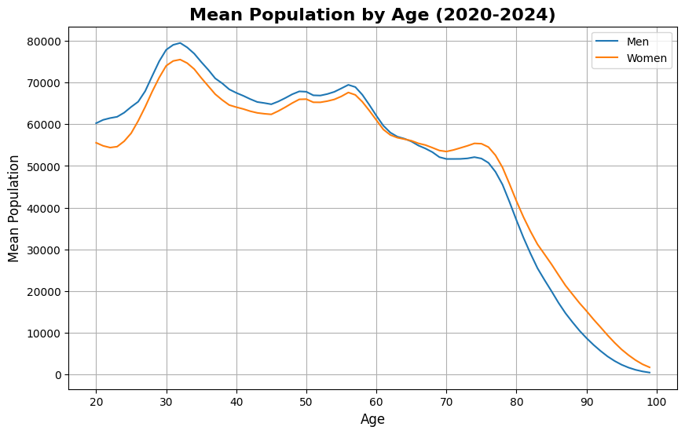

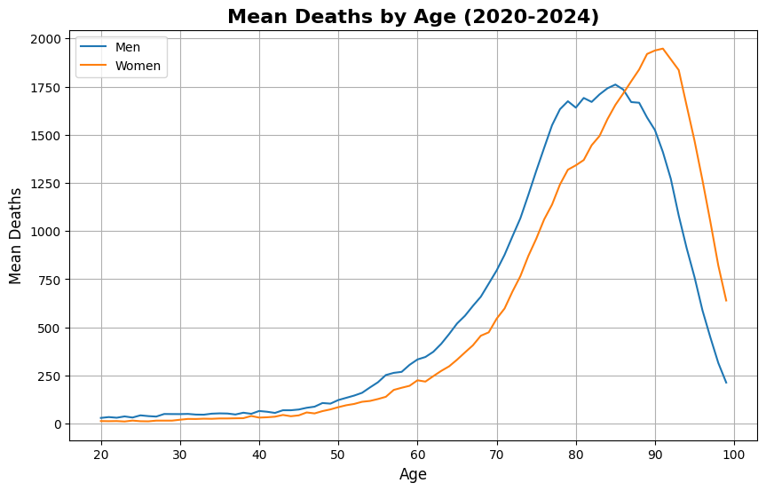

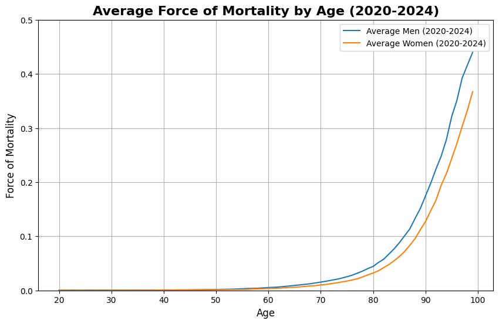

```
Men: alpha=0.0011319751, beta=0.0000013040, gamma=0.131
Women: alpha=0.0007312959, beta=0.0000006197, gamma=0.136
```

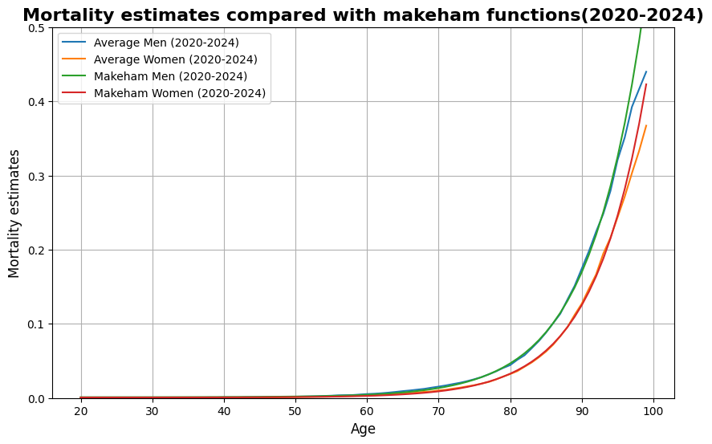

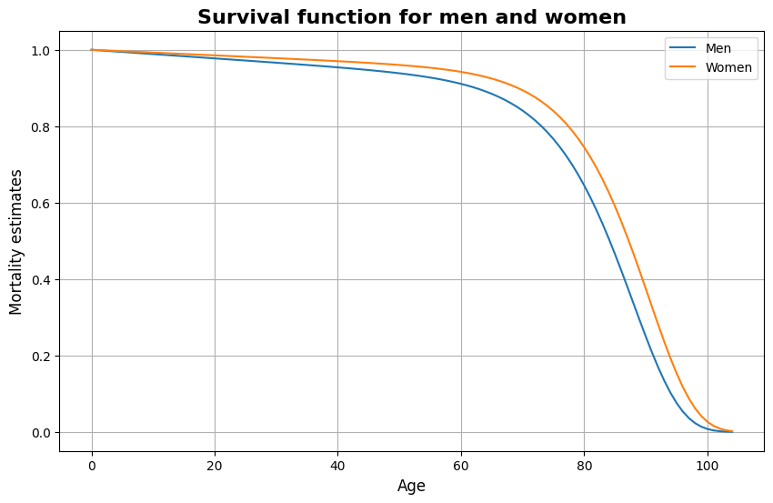

```
Men: Life expectancy = 79.76 years
Women: Life expectancy = 83.68 years
```

```python
import pandas as pd
import numpy as np
import matplotlib.pyplot as plt
from scipy.optimize import minimize_scalar
from scipy.integrate import quad


data = pd.read_excel('/content/Befolkningsdata.xlsx')


mean_population_men = []
mean_population_woman = []
mean_deaths_men = []
mean_deaths_women = []


# 5---------------------------------------------------------------------------
for j in range(81):
  current_row_index = j + 2
  mean_population_men.append(np.mean(data.iloc[current_row_index, 1:6]))
  mean_population_woman.append(np.mean(data.iloc[current_row_index, 6:11]))
  mean_deaths_men.append(np.mean(data.iloc[current_row_index, 11:16]))
  mean_deaths_women.append(np.mean(data.iloc[current_row_index, 16:21]))



ages = range(20, 20 + len(mean_population_men))

plt.figure(figsize=(10, 6))
plt.plot(ages, mean_population_men, label='Men')
plt.plot(ages, mean_population_woman, label='Women')
plt.title('Mean Population by Age (2020-2024)', fontsize=16, fontweight='bold')
plt.xlabel('Age', fontsize=12)
plt.ylabel('Mean Population', fontsize=12)
plt.grid(True)
plt.legend()
plt.show()

plt.figure(figsize=(10, 6))
plt.plot(ages, mean_deaths_men, label='Men')
plt.plot(ages, mean_deaths_women, label='Women')

plt.title('Mean Deaths by Age (2020-2024)', fontsize=16, fontweight='bold')
plt.xlabel('Age', fontsize=12)
plt.ylabel('Mean Deaths', fontsize=12)
plt.grid(True)
plt.legend()
plt.show()


# 6 a)--------------------------------------------------------------------------


# Lists to store average FoM for 2020-2024
avg_FoM_men = []
avg_FoM_women = []

for i in range(80):
  current_row_index = i + 2
  avg_FoM_men.append(np.sum(data.iloc[current_row_index, 11:16]) / np.sum(data.iloc[current_row_index, 1:6]))
  avg_FoM_women.append(np.sum(data.iloc[current_row_index, 16:21]) / np.sum(data.iloc[current_row_index, 6:11]))

ages = range(20, 20 + len(avg_FoM_men))
plt.figure(figsize=(10, 6))
plt.plot(ages, avg_FoM_men, label='Average Men (2020-2024)')
plt.plot(ages, avg_FoM_women, label='Average Women (2020-2024)')

plt.title('Average Force of Mortality by Age (2020-2024)', fontsize=16, fontweight='bold')
plt.xlabel('Age', fontsize=12)
plt.ylabel('Force of Mortality', fontsize=12)
plt.ylim([0, 0.5])
plt.grid(True)
plt.legend()
plt.show()


# 6 b)--------------------------------------------------------------------------

ages6b = np.arange(20,90,1)

def fit_makeham_from_mu(ages, mu_hat, g_bounds=(0, 1)):
    mu_hat = np.asarray(mu_hat, dtype=float)
    w = np.ones_like(mu_hat)
    Nw = w.sum()
    m  = (mu_hat).sum()

    def f1(g): return (np.exp(g*ages6b)).sum()
    def f2(g): return (np.exp(2*g*ages6b)).sum()
    def gfun(g): return (mu_hat*np.exp(g*ages6b)).sum()

    def squared_diff(g):
        F1, F2, G = f1(g), f2(g), gfun(g)
        alpha = (m*F2 - G*F1) / (Nw*F2 - F1**2)
        beta  = (m*F1 - Nw*G) / (F1**2 - Nw*F2)
        mu_fit = alpha + beta*np.exp(g*ages6b)
        return ((mu_hat - mu_fit)**2).sum()

    res = minimize_scalar(squared_diff, bounds=g_bounds, method='bounded')
    ghat = float(res.x)
    F1, F2, G = f1(ghat), f2(ghat), gfun(ghat)
    alpha = (m*F2 - G*F1) / (Nw*F2 - F1**2)
    beta  = (m*F1 - Nw*G) / (F1**2 - Nw*F2)
    return alpha, beta, ghat

alpha_m, beta_m, gamma_m = fit_makeham_from_mu(ages6b, avg_FoM_men[0:70])
alpha_w, beta_w, gamma_w = fit_makeham_from_mu(ages6b, avg_FoM_women[0:70])

fitted_FoM_men   = alpha_m + beta_m*np.exp(gamma_m*np.asarray(ages))
fitted_FoM_women = alpha_w + beta_w*np.exp(gamma_w*np.asarray(ages))

print(f"Men: alpha={alpha_m:.10f}, beta={beta_m:.10f}, gamma={gamma_m:.3f}")
print(f"Women: alpha={alpha_w:.10f}, beta={beta_w:.10f}, gamma={gamma_w:.3f}")

plt.figure(figsize=(10, 6))
plt.plot(ages, avg_FoM_men, label='Average Men (2020-2024)')
plt.plot(ages, avg_FoM_women, label='Average Women (2020-2024)')
plt.plot(ages, fitted_FoM_men, label='Makeham Men (2020-2024)')
plt.plot(ages, fitted_FoM_women, label='Makeham Women (2020-2024)')
plt.title('Mortality estimates compared with makeham functions(2020-2024)', fontsize=16, fontweight='bold')
plt.xlabel('Age', fontsize=12)
plt.ylabel('Mortality estimates', fontsize=12)
plt.ylim([0, 0.5])
plt.grid(True)
plt.legend()
plt.show()


# 6 c)--------------------------------------------------------------------------

ages_6c = np.arange(0,105,1)

def survival_func(alpha, beta, gamma, ages):
    return np.exp(-alpha * ages - (beta/gamma) * (np.exp(gamma*ages)-1))

l_men = survival_func(alpha_m, beta_m, gamma_m, ages_6c)
l_women = survival_func(alpha_w, beta_w, gamma_w, ages_6c)

plt.figure(figsize=(10, 6))
plt.plot(ages_6c, l_men, label='Men')
plt.plot(ages_6c, l_women, label='Women')
plt.title('Survival function for men and women', fontsize=16, fontweight='bold')
plt.xlabel('Age', fontsize=12)
plt.ylabel('Mortality estimates', fontsize=12)
plt.grid(True)
plt.legend()
plt.show()

# 6 d)--------------------------------------------------------------------------

def Life_expectancy(alpha, beta, gamma):
  f = lambda x: survival_func(alpha, beta, gamma, x)
  val, _ = quad(f, 0, 120)
  return val

Life_expectancy_men = Life_expectancy(alpha_m, beta_m, gamma_m)
Life_expectancy_women = Life_expectancy(alpha_w, beta_w, gamma_w)

print(f"Men: Life expectancy = {Life_expectancy_men:.2f} years")
print(f"Women: Life expectancy = {Life_expectancy_women:.2f} years")
```

### Task 7

```
Women: alpha=0.0007312959, beta=0.0000006197, gamma=0.136

Annual payout b = 165,793.31 SEK
```

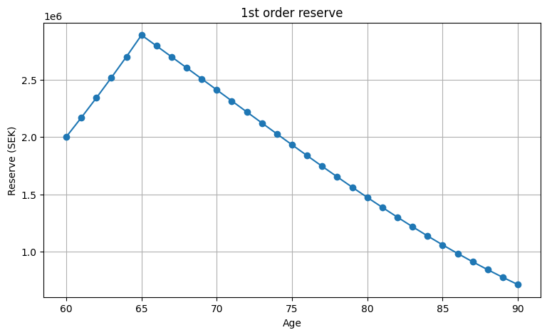

```
Reserve every 5th year:
 Age  Reserve (SEK)
  60     2000000.00
  65     2886922.45
  70     2409426.54
  75     1930840.58
  80     1472556.86
  85     1059284.34
  90      713471.17
```

```python
import pandas as pd
import numpy as np
import matplotlib.pyplot as plt
from scipy.optimize import minimize_scalar
# Från 6------------------------------------------------------------------------
data = pd.read_excel('/content/Befolkningsdata.xlsx')

mean_population_woman = []
mean_deaths_women = []

for j in range(81):
    current_row_index = j + 2
    mean_population_woman.append(np.mean(data.iloc[current_row_index, 6:11]))
    mean_deaths_women.append(np.mean(data.iloc[current_row_index, 16:21]))

avg_FoM_women = []
for i in range(80):
    current_row_index = i + 2
    avg_FoM_women.append(
        np.sum(data.iloc[current_row_index, 16:21]) /
        np.sum(data.iloc[current_row_index, 6:11])
    )

ages = range(20, 20 + len(avg_FoM_women))

ages6b = np.arange(20,90,1)

def fit_makeham_from_mu(ages, mu_hat, g_bounds=(0, 1)):
    mu_hat = np.asarray(mu_hat, dtype=float)
    w = np.ones_like(mu_hat)
    Nw = w.sum()
    m  = (mu_hat).sum()

    def f1(g): return (np.exp(g*ages6b)).sum()
    def f2(g): return (np.exp(2*g*ages6b)).sum()
    def gfun(g): return (mu_hat*np.exp(g*ages6b)).sum()

    def squared_diff(g):
        F1, F2, G = f1(g), f2(g), gfun(g)
        alpha = (m*F2 - G*F1) / (Nw*F2 - F1**2)
        beta  = (m*F1 - Nw*G) / (F1**2 - Nw*F2)
        mu_fit = alpha + beta*np.exp(g*ages6b)
        return ((mu_hat - mu_fit)**2).sum()

    res = minimize_scalar(squared_diff, bounds=g_bounds, method='bounded')
    ghat = float(res.x)
    F1, F2, G = f1(ghat), f2(ghat), gfun(ghat)
    alpha = (m*F2 - G*F1) / (Nw*F2 - F1**2)
    beta  = (m*F1 - Nw*G) / (F1**2 - Nw*F2)
    return alpha, beta, ghat

alpha_w, beta_w, gamma_w = fit_makeham_from_mu(ages6b, avg_FoM_women[0:70])
print(f"Women: alpha={alpha_w:.10f}, beta={beta_w:.10f}, gamma={gamma_w:.3f}")


def l_of_age(a, x0=0.0):
    return np.exp(-alpha_w*(a-x0) - (beta_w/gamma_w)*(np.exp(gamma_w*a)-np.exp(gamma_w*x0)))

def S_conditional(y, t_months):
    t = t_months/12.0
    return l_of_age(y+t)/l_of_age(y)
#-------------------------------------------------------------------------------

x=60; z=65
u=z-x
s=120-z
r_g=0.02; s_c=np.log(1+r_g)
P=120_000
Gx=2_000_000

t_pay = np.arange(12*u+1, 12*(u+s)+1, dtype=int)
t_pre = np.arange(1, 12*u+1, dtype=int)

EPV_pay_coeff = (S_conditional(x, t_pay) * np.exp(-s_c*t_pay/12.0)).sum()/12.0
EPV_pre_coeff = (S_conditional(x, t_pre) * np.exp(-s_c*t_pre/12.0)).sum()/12.0

b = (Gx + P*EPV_pre_coeff) / EPV_pay_coeff
print(f"\nAnnual payout b = {b:,.2f} SEK")

years_fwd = 30
ages = np.arange(x, x+years_fwd+1)

def V_at_age(y):
    t_prem  = max(0, 12*(z-y))
    t_first_pay = max(1, 12*(z-y)+1)

    if t_prem>0:
        t = np.arange(1, t_prem+1, dtype=int)
        EPVprem = (S_conditional(y,t)*np.exp(-s_c*t/12.0)).sum()/12.0 * P
    else:
        EPVprem = 0.0
    if y<120:
        t = np.arange(t_first_pay, 12*(120-y)+1, dtype=int)
        EPVpay  = (S_conditional(y,t)*np.exp(-s_c*t/12.0)).sum()/12.0 * b
    else:
        EPVpay = 0.0
    return EPVpay - EPVprem

V = np.array([V_at_age(y) for y in ages])


plt.figure(figsize=(9,5))
plt.plot(ages, V, marker='o')
plt.title('1st order reserve')
plt.xlabel('Age'); plt.ylabel('Reserve (SEK)'); plt.grid(True); plt.show()

take5_ages = np.arange(x, x+years_fwd+1, 5)
vals = [V[np.where(ages==a)[0][0]] for a in take5_ages]
reserve_table = pd.DataFrame({'Age':take5_ages, 'Reserve (SEK)':np.round(vals,2)})
print("\nReserve every 5th year: "); print(reserve_table.to_string(index=False))
```